# Introduction to R - class 1

Tomek Gaczorek; tomasz.gaczorek@doctoral.uj.edu.pl

04 10 2022

**!!! Description of exercises is in green !!!**

### 1. What is R?

R is an extremely powerful programming language, broadly used in the science for:

- data processing
- statistical analysis
- production of highly-customizable, publication quality graphs
- computer simulations
- … and much more

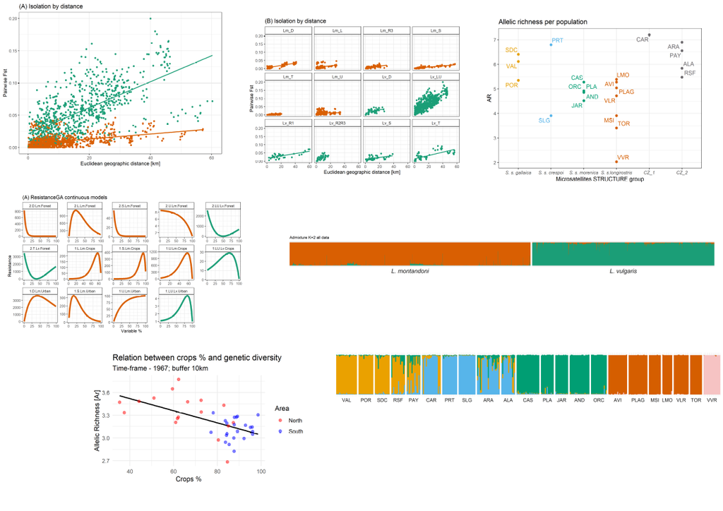

### 2. R installation

To install R for Windows follow the [link](https://ftp.fau.de/cran/bin/windows/base/) and then click on “Download R – *version_number* – for Windows”.  
To install R for OS X (Macs) follow the [link](https://ftp.fau.de/cran/) and then click on “Download R for (Mac) OS X”  
To install R for Linux type the lines below in the terminal. In case of any issues follow the extended instruction under the [link](https://ftp.fau.de/cran/) >> “Download R for Linux”

```bash
sudo apt-get update
sudo apt-get install r-base
```

Run R. You should see a window similar to the one below.

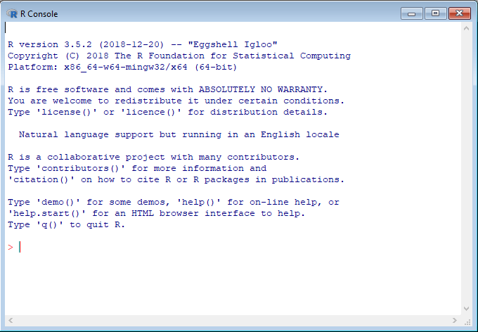

It is so called R console. Anything written and executed within a console will be interpreted (calculated) by R and will print out something in the console.

### 3. R as a typical calculator

R understands standard mathematical operators: + (addition), - (subtraction), * (multiplication), / (division) and ^ (power).

**Ex 1. Sum up all numbers from 1 to 10 using the ‘+’ operator.**  
Expected result:

```
[1] 55
```

**Ex 2. Raise the result of exercise 1 to the power of 5.**  
Expected result:

```
[1] 503284375
```

R also provides 2 additional operators:  
**%%** - *modulus* - returns the rest from the division  
**%/%** - *integer division* - returns how many times one number fits into another

**Ex 3. For numbers 10, 156, 557, 777 and 1055, check which are divisible by 7.**

Due to its unique role in science $\pi$ value can be obtained just by typing *pi*.

**Ex 4. Calculate the area of a circle if the radius equals 40 meters.**  
Expected result:

```
[1] 5026.548
```

**An advice**  
R uses the standard order of mathematical operations. However, it is usually a good practice to use parentheses.

Apart from that, there are also commonly used mathematical functions as:  
**log()** - natural logarithm  
**log10()** - logarithm base 10  
**exp()** - exponent, Euler number raised to a given power  
**sin()**, **cos()**, **tan()** - trigonometric functions  
**abs()** - absolute value  
You can use them by including the desired number inside the parentheses e.g. exponent of e for *exp()* or an angle in radians for any of trigonometric functions.

**Ex 5. Using the equation for Simpson’s diversity index and species frequencies shown below, calculate diversity for both populations separately. Which is more diversed (higher values reflect more diversed populations)?**  
$H_{S} = 1-\sum_{i = 1}^{S}p_i^2$ where:  
$p_i$ - frequency of given species  
S - number of species

| Frequencies | Population 1 | Population 2 |
| --- | --- | --- |
| species 1 | 0.8 | 0.2 |
| species 2 | 0.1 | 0.2 |
| species 3 | 0.1 | 0.6 |

Expected result:

```
[1] "Population 1"
```

```
[1] 0.34
```

```
[1] "Population 2"
```

```
[1] 0.56
```

### 4. Variables

Until you name something it does not exist in a computer memory! Any outcome of the execution of a command within the console perishes when the calculation is finished, unless it is assigned to a given name. Named objects within the computer memory are called “variables”. You can create one by using arrows (assignement symbol) in the following manner:  
*chosen_name <- object_to_be_saved*  
You can easily recall the value of the variable later on by typing its name.

**Ex 6. Try to save *5* as variable. Choose a variable name on your own. Then, type your variable’s name and press *Enter*.**  
Expected result:

```
[1] 5
```

**An advice**  
The variable name is case sensitive and cannot contain blank spaces or start with a digit. When you want to combine several words into one name use the underscore (_). By convention dots are used for function names and should be used with caution.

Since the variable is saved, its name can replace the actual value in any R commands e.g. if *2* is assigned to *x*, both *2+3* and *x+3* would result in *5*.

**Ex 7. Using the table below, calculate the range of species frequencies for both populations and save them as separate variables. Then using chosen names, calculate the absolute difference between ranges. Save it to a variable called *range_diff* and call it.**

| Frequencies | Population 1 | Population 2 |
| --- | --- | --- |
| species 1 | 0.8 | 0.2 |
| species 2 | 0.1 | 0.2 |
| species 3 | 0.1 | 0.6 |

Expected result:

```
[1] 0.3
```

Variables can also be overwritten. It is done by assigning a new object to the already used variable’s name. Remember, however, that once you overwrite the variable the old value disappears for good.

**Ex 8. Change variable *range_diff* by increasing its value by 20%. Call it.**  
Expected result:

```
[1] 0.36
```

Variables can store not only numbers. The other very popular type of data is a *string*. It is a text which behaves as a single object regardless of its length. To distinguish strings from variable names R requires usage of quotation marks around them.

**Ex 9. Save your name to the variable *my_name*. Call it.**

### 5. Functions

One of the usual ways to deal with your data in R is to use functions. They are simply lines of code saved in a computer memory that perform desired operations and often return a result.  
Functions we used before take only a single argument e.g. log() takes a number. However, it is rarely the case. List of function’s arguments and the way of usage can be found in function’s manual. It can be reached by typing *?* followed by the function’s name.**

**Ex 10. Open the manual for *paste()* function.**

Usually the manual consists of 7 sections:  
- DESCRIPTION - the aim of the function  
- USAGE - the syntax  
- ARGUMENTS - arguments passed to the function and their meaning  
- DETAILS - detailed description of the function behaviour  
- VALUE - outcome of the function  
- REFERENCES - often the scientific article function is based on - EXAMPLES

**Ex 11. Use** *paste()* **function to stick the following words together:** ‘I’, ‘am’, ‘using’ **and** ‘R’. **Don’t forget about quotation marks.**

Expected result:

```
[1] "I am using R"
```

Arguments passed to functions often have their own names.  
Distinctive names are crucial because many functions take multiple arguments that need to be distinguished. Such named arguments are passed in the following pattern: *argument_name = argument_value*.

**Ex 12. Use the same function as above but set another argument called** *sep* **(separator) to** ’_’

Expected result:

```
[1] "I_am_using_R"
```

Note that blank space was replaced with underscore. However, where did the blank spaces come from at the first space? The answer is that some arguments have their default values that would be taken if no value is put into function.  
In the above case the default value for *sep* argument is a blank space (” “).

**An advice**  
It is a good practice to use argument names while calling a function. Although, R can “guess” the argument name by the order in which arguments are typed, it can work improperly when the number of arguments is not strictly defined (“…” sign in function description).

### 6. Vectors

Vector is a series of numbers (or strings) that are saved as a single variable. A new vector can be created with *c()* function in the following manner: *c(value_1,value_2,value_3,…)*.

**Ex 13. Create a vector containing integers from 5 to 10 and save it to a variable. Call it.**  
Expected result:

```
[1]  5  6  7  8  9 10
```

**To create a vector of consecutive integers you can type the limits of the range separated by colon.**

**Ex 14. Create a vector containing integers from 1 to 100 and save it to a variable *one_to_hundred*. Call it.**  
Expected result:

```
  [1]   1   2   3   4   5   6   7   8   9  10  11  12  13  14  15  16  17  18
 [19]  19  20  21  22  23  24  25  26  27  28  29  30  31  32  33  34  35  36
 [37]  37  38  39  40  41  42  43  44  45  46  47  48  49  50  51  52  53  54
 [55]  55  56  57  58  59  60  61  62  63  64  65  66  67  68  69  70  71  72
 [73]  73  74  75  76  77  78  79  80  81  82  83  84  85  86  87  88  89  90
 [91]  91  92  93  94  95  96  97  98  99 100
```

**An advice**  
Note that concerning ranges, R is fully inclusive which means that both limits of the range will be included in the final outcome.

To create a vector of consecutive numbers which differ by a given value, use *seq()* function. Note that the function will return a vector so there is no need to use *c()*.

**Ex 15. Access *seq()* manual. Using *seq()* function, create a vector of numbers between 0 and 1 that differ by 0.1.**

```
 [1] 0.0 0.1 0.2 0.3 0.4 0.5 0.6 0.7 0.8 0.9 1.0
```

To create a vector of repeated values, use *rep()* function:

**Ex 16. Access *rep()* manual by typing *?rep* in console. Using *rep()* function, create a vector consisting of 1,2 and 3 repeated 20 times. Save it as a variable *repeated*.**

```
 [1] 1 2 3 1 2 3 1 2 3 1 2 3 1 2 3 1 2 3 1 2 3 1 2 3 1 2 3 1 2 3 1 2 3 1 2 3 1 2
[39] 3 1 2 3 1 2 3 1 2 3 1 2 3 1 2 3 1 2 3 1 2 3
```

All elements of a vector have to be of the same type. While trying to combine different types, R will try to reformat some of them.

**Ex 17. Create a vector from 1 to 4 with odd numbers typed as digits and even numbers typed as words. What is the outcome? Vector of integers or vector of strings?**

### 7. Vector machinations

Useful functions:  
**min()** - minimum value  
**max()** - maximum value  
**sum()** - sum up all numbers in a vector  
**prod()** - multiply all numbers in a vector  
**mean()** - average value  
**median()** - central value  
**length()** - number of elements in a vector  
**sort()** - sort values (default is ascending order, use *decreasing* argument to sort in descending order)  
**unique()** - return unique values  
**round()** - round numbers (to integers by default)

**Ex 18. Having a vector *one_to_hundred* calculate its mean and median**  
Expected results:

```
[1] 50.5
```

```
[1] 50.5
```

**Ex 19. Having a vector *repeated* sort it and return unique values.**  
Expected results:

```
 [1] 1 1 1 1 1 1 1 1 1 1 1 1 1 1 1 1 1 1 1 1 2 2 2 2 2 2 2 2 2 2 2 2 2 2 2 2 2 2
[39] 2 2 3 3 3 3 3 3 3 3 3 3 3 3 3 3 3 3 3 3 3 3
```

```
[1] 1 2 3
```

Vectors can be also used in typical mathematical operations. However there is one important rule: shorter vector will be repeated until it reaches length of longer one (single number is treated as vector of length 1).

Examples:

```r
c(1,2,3,4) + 5     # 5 is added to each element, the same as c(1,2,3,4) + c(5,5,5,5)
```

```
[1] 6 7 8 9
```

```r
c(1,2,3,4) + c(1,2)     # the same as c(1,2,3,4) + c(1,2,1,2)
```

```
[1] 2 4 4 6
```

**Ex 20. Having a vector *one_to_hundred*, raise each element to the power of 3. Save it to a variable called *power_3*.**  
Expected result:

```
  [1]       1       8      27      64     125     216     343     512     729
 [10]    1000    1331    1728    2197    2744    3375    4096    4913    5832
 [19]    6859    8000    9261   10648   12167   13824   15625   17576   19683
 [28]   21952   24389   27000   29791   32768   35937   39304   42875   46656
 [37]   50653   54872   59319   64000   68921   74088   79507   85184   91125
 [46]   97336  103823  110592  117649  125000  132651  140608  148877  157464
 [55]  166375  175616  185193  195112  205379  216000  226981  238328  250047
 [64]  262144  274625  287496  300763  314432  328509  343000  357911  373248
 [73]  389017  405224  421875  438976  456533  474552  493039  512000  531441
 [82]  551368  571787  592704  614125  636056  658503  681472  704969  729000
 [91]  753571  778688  804357  830584  857375  884736  912673  941192  970299
[100] 1000000
```

### 8. Accessing elements of a vector

**Vector can be subsetted in the following manner: *vector_name[element_index]***

**Ex 21. Return 15<sup>th</sup> element of the vector *power_3*.**  
Expected result:

```
[1] 3375
```

**Colon can be used for ranges just as for vector creation.**

**Ex 22. Return 2<sup>nd</sup> to 20<sup>th</sup> element of the vector *power_3*.**  
Expected result:

```
 [1]    8   27   64  125  216  343  512  729 1000 1331 1728 2197 2744 3375 4096
[16] 4913 5832 6859 8000
```

**To obtain multiple values, put a vector instead single position index.**

**Ex 23. Return 15<sup>th</sup>, 30<sup>th</sup> and 45<sup>th</sup> element of the vector *power_3*.**  
Expected result:

```
[1]  3375 27000 91125
```

**Ex 24. Create a vector including numbers from 1 to 10, 40 and 55. Save it to a variable. Return corresponding elements of the vector *power_3* with the use of previously saved variable.**  
Expected result:

```
 [1]      1      8     27     64    125    216    343    512    729   1000
[11]  64000 166375
```

**An advice**  
While creating a vector you can combine both ranges and single indexes with *c()* function.

### 9. Before leaving

**If you want me to check your code written during the class, type the commands below to save the R history. Change file’s name to include your surname and upload it on the Pegaz platform under Class 1 >> *R history* section.**

```r
savehistory(file = "my_history.txt")     # saves your R history to the file "my_history.txt"
getwd()                                  # displays where the file was saved
```

### 10. Next classes

In the following classes you will learn how to use R studio, save your code, rerun analysis and work with tables.

### 11. Homework

**Please, save all your commands in a text file (.txt) and upload it on the Pegaz platform under Class 1 >> *Homework* section.**

1. Create a vector with 12 elements which will correspond to the number of days each month has. Assume it is not a leap-year. Call it *days*.
2. Using vector *days* calculate mean number of days in a month.
3. Using vector *days* calculate the difference (in days) between the longest and the shortest month.
4. Modify vector *days* to obtain a vector of unique possible months’ lengths. Call it *months_length*.
5. Modify vector *days* and create a vector with the number of seconds each month has. Call it *seconds*.